# Madison Weather

Bret Larget

This R Markdown document includes contributions from Professor Jessi Kehe.

## Temperature Trends over Time

- We will examine trends in average temperature over time.

```r
## read in the data
official = read_csv("../../data/madison-weather-official-2020.csv",
                    col_types = cols( name = col_character(),
                                      date = col_date(format = ""),
                                      prcp = col_double(),
                                      snow = col_double(),
                                      snow_depth = col_double(),
                                      tmin = col_double(),
                                      tmax = col_double(),
                                      tavg = col_double()))
```

## Annual average temperature

- Calculate the average temperature per year
  - Select variables
  - Drop missing values
  - Group and summarize
- Plot versus the year
- Examine trends

```r
mw1 = official %>%
  ## select date and tavg; no other variables needed
  select(date, tavg) %>%
  ## drop any rows with missing data (this is why we did select() first)
  drop_na() %>%
  ## use the lubridate function year() to extract the year from the date
  mutate(year = year(date)) %>%
  ## group by year
  group_by(year) %>%
  ## calculate the average temperature by each year
  summarize(tavg = mean(tavg))

mw1
```

```
## # A tibble: 152 × 2
##     year  tavg
##    <dbl> <dbl>
##  1  1869  43.4
##  2  1870  47.8
##  3  1871  46.3
##  4  1872  44.0
##  5  1873  44.0
##  6  1874  46.5
##  7  1875  42.5
##  8  1876  45.4
##  9  1877  47.8
## 10  1878  49.8
## # … with 142 more rows
```

- Now, plot the data

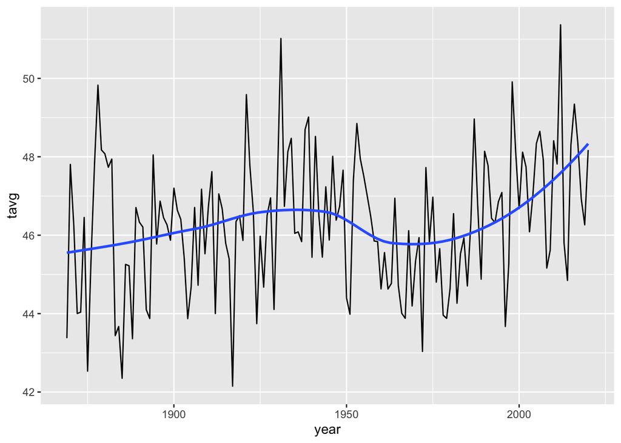

```r
ggplot(mw1, aes(x = year, y = tavg)) +
  geom_line() +
  geom_smooth(se = FALSE)
```

- The pattern we see is:
  - the average temperature increased from about 45.5 degrees Fahrenheit in 1870 up to about 46.8 degrees around 1940.
  - then, temperatures went down for about 30 years, bottoming out in 1970
  - since then, the average temperature has increased over two degrees Fahrenheit
  - the rate that the average temperature is increasing is accelerating
- We could improve the plot with better labels and a title

## Temperature by 30-year period

- Meteorologists often determine weather norms by averaging over a 30-year period.
- Let’s find the means of the maximum, average, and minimum temperatures by period and month.
  - We will ignore the years 1869 and 1870 to create five 30-year periods.
  - The first period is 1871 - 1900, the second 1901 - 1930, and so on.

```r
## add year and period variables to the official data set
## Note that the formula floor( (year - 1841)/30 )*30 + 1841 maps:
##    the years from 1841 to 1870 to 1841;
##    the years from 1871 to 1900 to 1871; and so on
## This value plus 29 is the end of the period
## Use str_c() from stringr to combine the different strings into the period value
##   1841 - 1870, 1871 - 1900, 1901 - 1930, 1931 - 1960, 1961 - 1990, 1991 - 2020
official = official %>%
  mutate(year = year(date),
         month = month(date, label = TRUE),
         period1 = floor( (year - 1841)/30 )*30 + 1841,
         period = str_c(period1, "-", period1 + 29))

## Now group by period and month and calculate the averages
mw2 = official %>%
  filter(year > 1870) %>%
  select(date, year, month, period, tmin, tavg, tmax) %>%
  drop_na() %>%
  group_by(period, month) %>%
  summarize(n = n(), tmin = mean(tmin), tavg = mean(tavg), tmax = mean(tmax))
```

- Plot the data
  - Use different facets by month
  - Line plots
  - Line color associated with min / avg / max

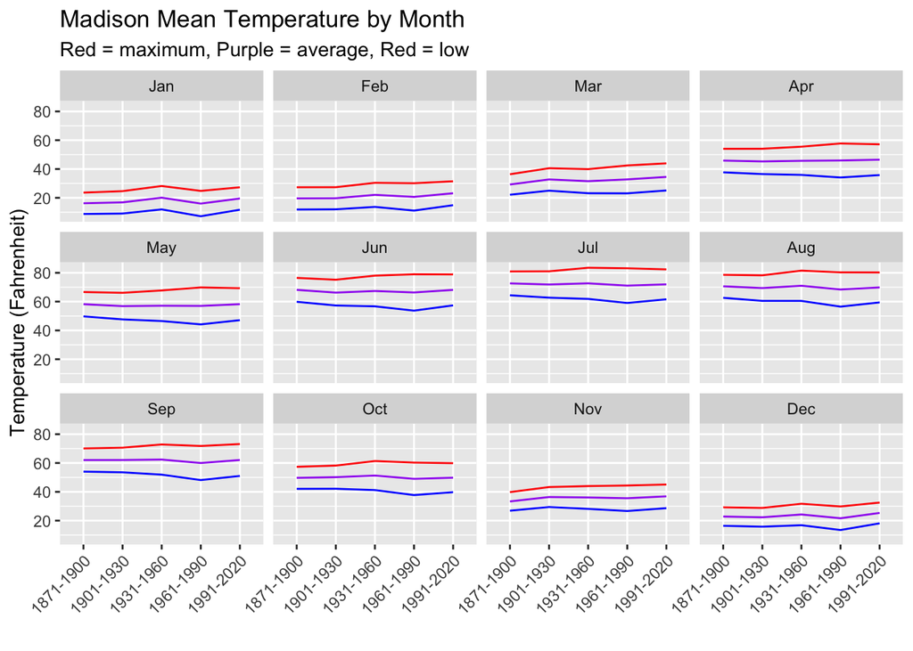

```r
g = ggplot(mw2, aes(x = period)) +
  # group -> to connect each point, if it is geom_point then do not have to do it
  geom_line(aes(y = tmin, group = 1), color = "blue") +
  geom_line(aes(y = tavg, group = 2), color = "purple") +
  geom_line(aes(y = tmax, group = 3), color = "red") +
  xlab("") +
  ylab("Temperature (Fahrenheit)") +
  ggtitle("Madison Mean Temperature by Month",
          subtitle = "Red = maximum, Purple = average, Red = low") +
  theme( axis.text.x = element_text(angle = 45, hjust=1)) +
  facet_wrap( ~ month)

g
```

- If we use different scales for each month, it will be easier to see trends within the months

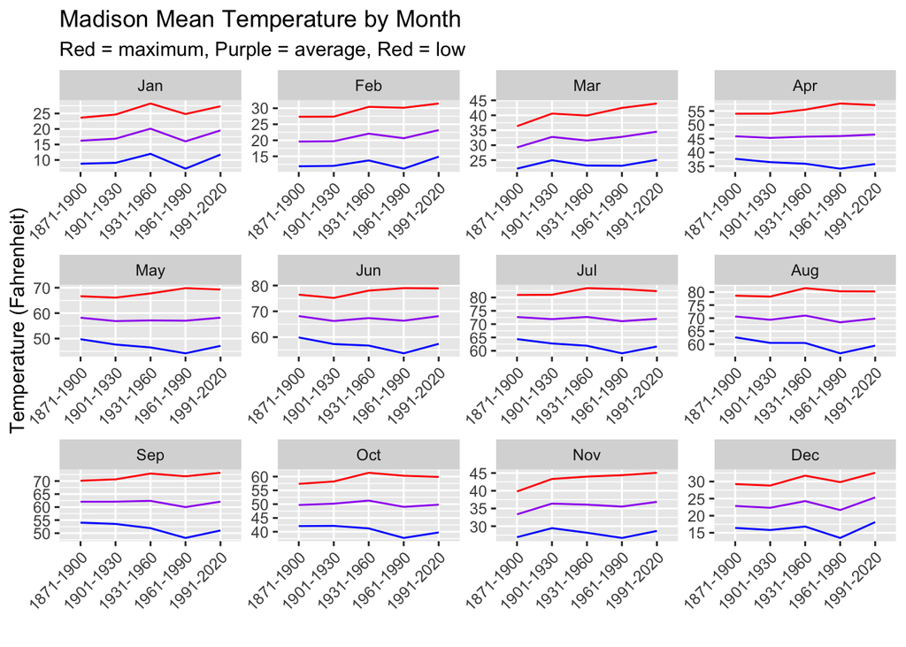

```r
g +
  facet_wrap( ~ month, scales = "free")
```

- There are differences among months in changes in average temperatures over time
- The largest increases in maximum temperature have occured in the colder months, November through March.
- Many months saw a decrease in mean low temperature, with some trending higher in the past thirty years

# Lecture: Daily Temperature Records

- Find the daily maximum and minimum temperatures for each day of the year in different data frames
- Record the year and the temperature for each record
- If there are ties, have a separate row for each year
- So, the resulting tables may have more than 366 rows.
- The command `slice_max()` will do what we want, finding the top values including ties.

## Temperature records

- Begin by re-reading in the official weather data
- Add year, month, and day variables
- Select the maximum temperature and time variables

```r
## re-read in the data
official = read_csv("../../data/madison-weather-official-2020.csv",
                    col_types = cols( name = col_character(),
                                      date = col_date(format = ""),
                                      prcp = col_double(),
                                      snow = col_double(),
                                      snow_depth = col_double(),
                                      tmin = col_double(),
                                      tmax = col_double(),
                                      tavg = col_double()))
```

- Add the time variables

```r
official = official %>%
  mutate(year = year(date), month = month(date, label=TRUE), day = day(date))
```

- Calculations for record high and low maximum and minimum daily temperatures

```r
daily_tmax_high = official %>%
  select(date, year, month, day, tmax) %>%
  drop_na() %>%
  group_by(month, day) %>%
  slice_max(tmax, n=1) %>%
  ungroup()

daily_tmax_low = official %>%
  select(date, year, month, day, tmax) %>%
  drop_na() %>%
  group_by(month, day) %>%
  slice_min(tmax, n=1) %>%
  ungroup()

daily_tmin_high = official %>%
  select(date, year, month, day, tmin) %>%
  drop_na() %>%
  group_by(month, day) %>%
  slice_max(tmin, n=1) %>%
  ungroup()

daily_tmin_low = official %>%
  select(date, year, month, day, tmin) %>%
  drop_na() %>%
  group_by(month, day) %>%
  slice_min(tmin, n=1) %>%
  ungroup()
```

## Questions

> On what date did Madison have the highest recorded temperature? What was the this temperature and how many different times was it achieved?

```r
daily_tmax_high %>%
  slice_max(tmax, n=1)
```

```
## # A tibble: 1 × 5
##   date        year month   day  tmax
##   <date>     <dbl> <ord> <int> <dbl>
## 1 1936-07-14  1936 Jul      14   107
```

- On July 14, 1936, Madison had an all-time high temperature of 107.
- This is the only date with a high temperature this high

> Which dates have the most ties for the highest temperature?

```r
daily_tmax_high %>%
  count(month, day) %>%
  ungroup() %>%
  slice_max(n)
```

```
## # A tibble: 1 × 3
##   month   day     n
##   <ord> <int> <int>
## 1 May      17     5
```

```r
daily_tmax_high %>%
  filter(month == "May", day == 17)
```

```
## # A tibble: 5 × 5
##   date        year month   day  tmax
##   <date>     <dbl> <ord> <int> <dbl>
## 1 1906-05-17  1906 May      17    86
## 2 1962-05-17  1962 May      17    86
## 3 1971-05-17  1971 May      17    86
## 4 1987-05-17  1987 May      17    86
## 5 2001-05-17  2001 May      17    86
```

- The May 17 record high of 86 degrees has been achieved five times: 1906, 1962, 1971, 1987, and 2001.

> What is the record latest date in the spring where the daily minimum temperature was below 32 degrees Fahrenheit? In which years did this occur?

```r
daily_tmin_low %>%
  filter(month < "Jul", tmin < 32) %>%
  arrange(desc(month), desc(day)) %>%
  head()
```

```
## # A tibble: 6 × 5
##   date        year month   day  tmin
##   <date>     <dbl> <ord> <int> <dbl>
## 1 1972-06-10  1972 Jun      10    31
## 2 1965-05-30  1965 May      30    30
## 3 1965-05-29  1965 May      29    30
## 4 1971-05-27  1971 May      27    31
## 5 1983-05-26  1983 May      26    30
## 6 1988-05-25  1988 May      25    30
```

- On June 10, 1972, the low temperature in Madison was 31 degrees Fahrenheit. This is the latest spring frost recorded.